# The Risk Premia Harvesting Strategy

## Get Library Dependencies and Set Data Location

In order to run this code, you’ll need to specify the path to your Bootcamp folder.

Set DATA_FOLDER to the location of your FXBootcamp resilio folder.

## Get Asset Price Data and Calculate Returns

The following loads long term asset-class total return data from your Resilio folder. Then it calculates daily returns, merges the data and stores them in the xts object returns_daily.

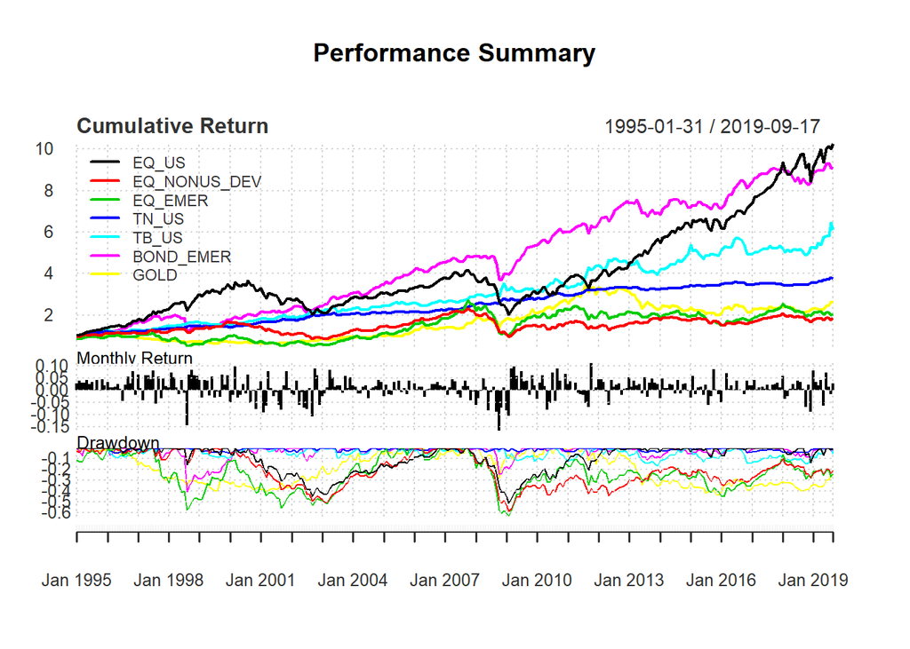

```r
prices_from_resilio <- function(filename, date_format="%Y%m%d") {
  prices = read.table(paste0(DATA_FOLDER, '/RiskPremia', '/', filename, '.csv'), header=TRUE, sep=",", row.names="Date")
  prices <- as.xts(prices, order.by = as.Date(rownames(prices), format = date_format))

  # calculate returns
  returns <- Return.calculate(prices$Close)
  prices$Cum_Return = rep(1, length(prices$Close))
  prices$Cum_Return[-1] = cumprod(1+returns[-1])

  return(prices)
}

# US Equity price series generated from VFINX mutual fund prices
EQ_US_df <- prices_from_resilio('VFINX')
EQ_US <- EQ_US_df$Cum_Return

# US Bond total return index generated from VBMFX mutual fund prices
BOND_US_df <- prices_from_resilio('VBMFX')
BOND_US <- BOND_US_df$Cum_Return

# US Intermediate Treasury Notes
TN_US_df <- prices_from_resilio('VFITX')
TN_US <- TN_US_df$Cum_Return

# US Long Term Treasury Bond
TB_US_df <- prices_from_resilio('VUSTX')
TB_US <- TB_US_df$Cum_Return

# Real Estate
RE_US_df <- prices_from_resilio('VGSIX')
RE_US <- RE_US_df$Cum_Return

# make extended gold data
source(paste0(DATA_FOLDER, '/Code/risk-premia/gold_processing.R'))

# Gold total return index generated by extending GSCI Gold index back with Gold spot prices
GOLD_df <- read.table(paste0(DATA_FOLDER, '/RiskPremia/extended_GCSI.csv'), header=TRUE, sep=",")
GOLD <- as.xts(GOLD_df$Cum_Ret, order.by = as.Date(GOLD_df[,1]))

# Commodities
COM_df <- prices_from_resilio('.SPGSCITR-I')
COM <- COM_df$Cum_Return

# Treasury bill returns from VFISX mutual fund prices
TBILL_US_df <- prices_from_resilio('VFISX')
TBILL_US <- TBILL_US_df$Cum_Return

# Non-US Developed Markets Equity total return index generated from XMSC MSCI index prices
EQ_NONUS_DEV_df <- prices_from_resilio('XMSC-F')
EQ_NONUS_DEV <- EQ_NONUS_DEV_df$Cum_Return

# Emerging Markets Equity total return index generated from MXEA MSCI index prices
EQ_EMER_df <- prices_from_resilio('MXEA-F')
EQ_EMER <- EQ_EMER_df$Cum_Return

# International Bonds total return index generated from Benham International Bond Fund prices
BOND_NONUS_df <- prices_from_resilio('BEGBX')
BOND_NONUS <- BOND_NONUS_df$Cum_Return

# Emerging Markets Bond total return index generated from T Rowe Price Emerging Markets Bond Fund
BOND_EMER_df <- prices_from_resilio('PREMX')
BOND_EMER <- BOND_EMER_df$Cum_Return

# Merge Data
stock_index <- na.locf(merge(EQ_US, EQ_NONUS_DEV, join = 'left'))
stock_index <- na.locf(merge(stock_index, EQ_EMER, join = 'left'))
fi_index <- na.locf(merge(TN_US, TB_US))
fi_index <- na.locf(merge(fi_index, BOND_EMER, join = 'left'))
index <- na.omit(na.locf(merge(merge(stock_index, fi_index), GOLD, join = 'left')))
colnames(index) <- c('EQ_US', 'EQ_NONUS_DEV', 'EQ_EMER', 'TN_US', 'TB_US', 'BOND_EMER', 'GOLD')

# Use to subset data range if you want an out-of-sample period.
# This notebook is just presenting the strategy, so we use the whole period.
sample <- index

# Calculate daily discrete returns
returns_daily <- na.omit(Return.calculate(sample, method = 'discrete'))
returns_monthly <- na.omit(Return.calculate(sample[endpoints(sample, on='months')], method = 'discrete'))

# clean emerging market data which has some bad data around 2017
returns_daily$EQ_EMER <- replace(returns_daily$EQ_EMER, abs(returns_daily$EQ_EMER) >  0.2, 0)

# Chart it to make sure everything looks as expected
charts.PerformanceSummary(returns_monthly, wealth.index = TRUE, legend.loc = 'topleft', main = 'Performance Summary')
```

## Strategy Code

The strategy code is below.

Most of the heavy lifting is done by the function *get_unlevered_target_weights*

This function returns the weights to assign to each asset.

The default values are the values we are trading in the Robot Wealth trading book.

The 3 main parts of the strategy are included in 3 separate functions.

- get_srp_weights takes asset class returns and calculates the Simple Risk Parity weights
- get_cor_adjustments calculates the adjustments to weights based on average pairwise correlations
- get_momo_adjustments calculates adjustments to weights based on an ensemble of momentum features.

```r
get_srp_weights <- function(rets, lookback=90, rebal = 22, equalise = c('volatility', 'variance')) {
  n_assets <- ncol(rets)
  vols <- na.omit(apply.rolling(rets[,1], width=lookback, by=rebal, FUN='StdDev.annualized'))
  for (i in 2:n_assets) {
    vols <- merge(vols, na.omit(apply.rolling(rets[,i], width=lookback, by=rebal, FUN='StdDev.annualized')))
  }
  if (equalise == 'variance') {
    raw_weights <- 1/vols^2
  } else {
    # else equalise volatility
    raw_weights <- 1/vols
  }
  weights <- raw_weights / rowSums(raw_weights) # Normalise weights to add to 1
  colnames(weights) <- colnames(rets)
  return(weights)
}

get_cor_adjustments <- function(rets, covar_lookback = 90, vol_weights, covarmethod=c('covariance','correlation')) {
  # Get average pairwise covariance based weights
  rebal_indexes <- index(vol_weights)
  cov_weights <- xts(matrix(0, length(rebal_indexes), ncol(rets)), order.by = index(rets[rebal_indexes]))
  colnames(cov_weights) <- colnames(rets)
  for (i in 1:length(rebal_indexes)) {
    j <- rebal_indexes[i]
    rets_roll_sample <- rets[seq(j-covar_lookback, j, 1)]
    if (covarmethod == 'correlation') {
      sample_cov <- cor(rets_roll_sample)
    } else {
      sample_cov <- cov(rets_roll_sample)
    }
    sample_pairwise_avg <- rowMeans(sample_cov)
    # scale to a gaussian between 0 and 1
    sample_gaussian_scale <- 1 - pnorm((sample_pairwise_avg - mean(sample_pairwise_avg)) / sd(sample_pairwise_avg))
    sample_weights <- sample_gaussian_scale / sum(sample_gaussian_scale)
    cov_weights[i,] <- sample_weights
  }
  # Set adjustments to sum to zero over all assets
  norm_weights <- (cov_weights / rowSums(cov_weights)) - (1/ncol(cov_weights))
  return(norm_weights)
}

# Return cross-sectional zscore of total return momentum
get_momo_adjustments <- function(rets, formation_period = 6 * 22, vol_weights) {
  synthetic_prices <- cumprod(1+rets)
  rebal_indexes <- index(vol_weights)
  momo <- na.omit(xts::lag.xts(TTR::ROC(synthetic_prices, n=formation_period, type='discrete'),1))[rebal_indexes]
  momo_weights <- xts(matrix(0, length(index(momo)), ncol(vol_weights)), order.by = index(momo))
  colnames(momo_weights) <- colnames(vol_weights)
  # Iterate through and normalise to zscore
  for(i in 1:nrow(momo)) {
    r <- momo[i]
    rd <- coredata(r)
    zscale <- (r - mean(rd)) / sd(rd)
    momo_weights[i,] <- zscale
  }
  return(momo_weights)
}

# Return cross-sectional zscore of slope of moving average
get_sma_slope_adjustment <- function(rets, formation_period = 6 * 22, vol_weights) {
  synthetic_prices <- cumprod(1+rets)
  rebal_indexes <- index(vol_weights)
  sma <- synthetic_prices
  sma[] <- NA
  for (i in 1:ncol(synthetic_prices)) {
    sma[,i] <- TTR::SMA(synthetic_prices[,i], n =formation_period)
  }
  sma_slope <- sma / xts::lag.xts(sma) - 1
  momo <- na.omit(xts::lag.xts(sma_slope, 1))[rebal_indexes]
  momo_weights <- xts(matrix(0, length(index(momo)), ncol(vol_weights)), order.by = index(momo))
  colnames(momo_weights) <- colnames(vol_weights)
  # Iterate through and normalise to zscore
  for(i in 1:nrow(momo)) {
    r <- momo[i]
    rd <- coredata(r)
    zscale <- (r - mean(rd)) / sd(rd)
    momo_weights[i,] <- zscale
  }
  return(momo_weights)
}

adjust_weights <- function(volweights, covaradjustments, shrinkagemultiplier) {
  w <- volweights * (1 + (covaradjustments * shrinkagemultiplier))
  return(w / rowSums(w)) # Ensure all weights sum to 1
}

adjust_weights_momo <- function(baseweights, momoadjustments, zscorecutoff = 0, multiplier = 0.1) {
  w <- baseweights * (1 + ((momoadjustments >= zscorecutoff) * multiplier))
  return (w / rowSums(w)) # Ensure all weights sum to 1
}

get_unlevered_target_weights <- function(ret, rebal=22, vol_lookback=90, cor_lookback=120, cor_shrinkage=1, adjust_momo = TRUE, momo_multiplier = 0.1) {
  volw <- get_srp_weights(ret, lookback=vol_lookback, rebal=rebal, equalise='volatility')
  coradjust <- get_cor_adjustments(ret, covar_lookback = cor_lookback, volw, covarmethod='correlation')
  coradjustweights <- adjust_weights(volw, coradjust, cor_shrinkage)

  # Get total return momentum adjustments at 3, 6, 9, 12 month lookbacks
  momoadjust3 <- get_momo_adjustments(ret, formation_period = 3*22, vol_weights = volw)
  momoadjustweights <- adjust_weights_momo(coradjustweights, momoadjust3, zscorecutoff = 0, multiplier = momo_multiplier)
  momoadjust6 <- get_momo_adjustments(ret, formation_period = 6*22, vol_weights = volw)
  momoadjustweights <- adjust_weights_momo(momoadjustweights, momoadjust6, zscorecutoff = 0, multiplier = momo_multiplier)
  momoadjust9 <- get_momo_adjustments(ret, formation_period = 9*22, vol_weights = volw)
  momoadjustweights <- adjust_weights_momo(momoadjustweights, momoadjust9, zscorecutoff = 0, multiplier = momo_multiplier)
  momoadjust12 <- get_momo_adjustments(ret, formation_period = 12*22, vol_weights = volw)
  momoadjustweights <- adjust_weights_momo(momoadjustweights, momoadjust12, zscorecutoff = 0, multiplier = momo_multiplier)

  # Get sma slope adjustments
  smaadjust3 <- get_sma_slope_adjustment(ret, formation_period = 3*22, vol_weights = volw)
  smaadjustweights <- adjust_weights_momo(momoadjustweights, smaadjust3, zscorecutoff = 0, multiplier = momo_multiplier)
  smaadjust6 <- get_sma_slope_adjustment(ret, formation_period = 6*22, vol_weights = volw)
  smaadjustweights <- adjust_weights_momo(smaadjustweights, smaadjust6, zscorecutoff = 0, multiplier = momo_multiplier)
  smaadjust9 <- get_sma_slope_adjustment(ret, formation_period = 9*22, vol_weights = volw)
  smaadjustweights <- adjust_weights_momo(smaadjustweights, smaadjust9, zscorecutoff = 0, multiplier = momo_multiplier)
  smaadjust12 <- get_sma_slope_adjustment(ret, formation_period = 12*22, vol_weights = volw)
  smaadjustweights <- adjust_weights_momo(smaadjustweights, smaadjust12, zscorecutoff = 0, multiplier = momo_multiplier)
  return(smaadjustweights)
}

get_levered_target_weights <- function(rets, unlevered_weights, vol_target = 0.1, vol_lookback = 90, maxleverage = 3) {
  # Assume we're not rebalancing any more frequently than previously
  dailyweights <- xts(matrix(NA, nrow(rets), ncol(rets)), order.by = index(rets))
  dailyweights[index(unlevered_weights),] <- coredata(unlevered_weights)
  dailyweights <- na.omit(na.locf(dailyweights))
    # Now scale the returns by the asset weights
  scaleret <- xts::lag.xts(dailyweights,1) * rets
  colnames(scaleret) <- colnames(rets)
  unl_port_returns <- xts(rowSums(scaleret), order.by = index(scaleret))

  rebal_indexes <- index(unlevered_weights)
  lev_weights <- xts(matrix(0, length(rebal_indexes), ncol(rets)), order.by = index(rets[rebal_indexes]))
  colnames(lev_weights) <- colnames(rets)
  for (i in 2:length(rebal_indexes)) {
    j <- rebal_indexes[i]
    rets_roll_sample <- unl_port_returns[seq(j-vol_lookback, j, 1)]
    vol_forecast <- StdDev.annualized(rets_roll_sample)
    weight_multiplier <- vol_target / vol_forecast[1]
    if(weight_multiplier > maxleverage) weight_multiplier <- maxleverage
    lev_weights[i,] <- weight_multiplier * unlevered_weights[i,]
  }
  return(lev_weights)
}
```

## Strategy Analysis

This suite of functions is used to assess the performance of the strategy.

It aggregates data at a quarterly level and outputs the following analytical charts:

- Realised annualised volatility for each asset - quarterly timeseries
- Realised annualised voaltility area chart
- Realised Volatility as a % of Total - Time Series
- Realised Volatility as a % of Total - Area Chart
- Risk Contribution Time Series
- Risk Contribution Time Series - Area Chart
- Trade Size Time Series - as proxy for trading costs / turnover
- Trade Size Time Series Area Chart - as proxy for trading costs / turnover
- Downside Risk Measures
- Top 5 Drawdowns
- Asset Weights
- Asset Weights - Area chart
- Tracking Error and Summary Statistics
- Portfolio Performance Time Series

Primarily, we are looking to see that the heuristic ERC algorithm does a good job of keeping asset level risk contributions relatively stable.

We are also looking at turnover and strategy performance, of course.

Largely the strategy development process was a job of balancing trade-offs trying to minimise both ERC tracking errors and trading costs.

```r
# Convert xts to df for plotting
xts_to_tidy_df <- function(x) {
  df <- cbind(index(x), as.data.frame(coredata(x)))
  colnames(df)[1] <- 'Date'
  gather(df, key='Asset', value='Value', -Date)
}

# Calculate marginal contribution to risk (where risk = std of returns)
# Adapted from FRAPO package
calc_mrc <- function (weights, Sigma, percentage = TRUE)
{
    Sigma <- as.matrix(Sigma)
    if (!isSymmetric(Sigma)) {
        stop("Object provided for 'Sigma' is not a symmetric matrix.\n")
    }
    w <- as.vector(weights)
    if (length(w) != ncol(Sigma)) {
        stop("Length of 'weights' vector differs from row/column dimension of 'Sigma'.\n")
    }
    sigma <- c(sqrt(t(w) %*% Sigma %*% w))
    sw <- Sigma %*% w
    dw <- c(w * sw/sigma)
    ifelse(percentage, res <- dw/sum(dw) * 100, res <- dw)
    return(res)
}

# Performance summary function.
# Returns summary details and prints charts and tables as side effects
riskperformance <- function(ret, weights, samplefreq = 'quarters', plot = TRUE, margin_cost = 0) {
  # ret <- returns_daily[,-5]
  # weights <- adjweights
  dailyweights <- xts(matrix(NA, nrow(ret), ncol(ret)), order.by = index(ret))
  dailyweights[index(weights),] <- coredata(weights)
  dailyweights <- na.omit(na.locf(dailyweights))

    # Now scale the returns by the asset weights
  scaleret <- xts::lag.xts(dailyweights,1) * ret
  colnames(scaleret) <- colnames(ret)

  # Get trades as percentage of portfolio
  tradesize <- na.omit(abs(dailyweights - xts::lag.xts(dailyweights)))
  totaltrade <- rowSums(tradesize)

  # Get monthly endpoints
  monthend <- endpoints(scaleret, on = samplefreq)[-1] # remove the first zero from the endpoints vector
  medt <- index(scaleret[monthend])

  # Create xts objects to hold volatilities and risk contributions
  vol_xts <- xts(matrix(NA, length(medt), ncol(ret)), order.by = index(scaleret[medt]))
  mrc_xts <- xts(matrix(NA, length(medt), ncol(ret)), order.by = index(scaleret[medt]))
  ts_xts <- xts(matrix(NA, length(medt), ncol(ret)), order.by = index(scaleret[medt]))
  colnames(vol_xts) <- colnames(mrc_xts) <- colnames(ts_xts) <- colnames(ret)

  i <- medt[1]
  for (n in 2:length(medt)) {
    j <- medt[n]
    r <- scaleret[paste0(i,'::',j)] # Get returns over window
    # Volatility
    vols <- StdDev.annualized(r) # Estimate volatility of each asset
    vol_xts[i,] <- vols
    # MRCD
    mrc <- calc_mrc(rep(1, ncol(scaleret)), cov(r)) # Estimate risk contribution of each asset (setting weights to zero)
    mrc_xts[i,] <- mrc
    # Trades
    ts <- colSums(tradesize[paste0(i,'::',j)])
    ts_xts[i,] <- ts
    i <- j
  }

  vol_xts <- na.omit(vol_xts)
  prop_xts <- vol_xts / rowSums(vol_xts)
  mrc_xts <- na.omit(mrc_xts)
  ts_xts <- na.omit(ts_xts)


  # Realised volatility tracking error
  trackerror_vol <- mean(rowMeans(abs(prop_xts - 1/ncol(prop_xts)))) * 100

  # Calculate mean tracking error on MRC
  trackerror_mrc <- mean(rowMeans(abs(mrc_xts - 100/ncol(mrc_xts))))

  # Tradesize
  mean_tradesize <- mean(rowSums(ts_xts))

  # Performance
  portfolio_returns <- xts(rowSums(scaleret), order.by=index(scaleret))
  # Subtract the cost of leverage if appropriate
  if (margin_cost != 0) {
    # Look at cost of leverage
    port_weights <- xts(rowSums(dailyweights), order.by = index(dailyweights))
    margin <- port_weights - 1
    marginreturn <- margin * (margin_cost / 360) # Estimating margin cost at annualised % / 360
    portfolio_returns <- portfolio_returns - marginreturn
  }

  t <- table.AnnualizedReturns(portfolio_returns)
  cagr <- t[,1][1] * 100
  sharpe <- t[,1][3]
  perf <- data.frame(trackerror_vol, trackerror_mrc, mean_tradesize, cagr, sharpe)

  if (plot == TRUE) {
    # Realised volatility
    print(plot(vol_xts, main = 'Realised Volatility', legend.loc='topleft'))
    vol_df <- xts_to_tidy_df(vol_xts)
    print(ggplot(vol_df, aes(x=Date, y=Value, fill=Asset)) + geom_area() + ggtitle('Realised Volatility'))

    # Realised volatility %
    print(plot(prop_xts, main = 'Realised Volatility %', legend.loc='topleft'))
    prop_df <- xts_to_tidy_df(prop_xts)
    print(ggplot(prop_df, aes(x=Date, y=Value, fill=Asset)) + geom_area() + ggtitle('Realised Volatility as Proportion of Total'))
    # Calculate mean tracking error (as %age)
    trackerror_vol <- mean(rowMeans(abs(prop_xts - 1/ncol(prop_xts)))) * 100

    #Risk contribution
    print(plot(mrc_xts, main = 'Risk Contribution', legend.loc='topleft'))
    mrc_df <- xts_to_tidy_df(mrc_xts)
    print(ggplot(mrc_df, aes(x=Date, y=Value, fill=Asset)) + geom_area() + ggtitle('Risk Contribution'))
    # Calculate mean tracking error on MRC
    trackerror_mrc <- mean(rowMeans(abs(mrc_xts - 100/ncol(mrc_xts))))

    # Tradesize
    print(plot(ts_xts, main='Trade Size', legend.loc='topleft'))
    tradesize_df <- xts_to_tidy_df(ts_xts)
    print(ggplot(tradesize_df, aes(x=Date, y=Value, fill=Asset)) + geom_area() + ggtitle('Rebalance Trades'))
    mean_tradesize <- mean(rowSums(ts_xts))

    # Weights
    print(plot(weights, main='Asset weights', legend.loc='topleft'))
    weights_df <- xts_to_tidy_df(weights)
    print(ggplot(weights_df, aes(x=Date, y=Value, fill=Asset)) + geom_area() + ggtitle('Asset Weights'))

    # Performance
    print(table.DownsideRisk(portfolio_returns))
    print(table.Drawdowns(portfolio_returns))
    charts.PerformanceSummary(portfolio_returns, main = 'Portfolio Returns')
    print(perf)
  }
  return(perf)
}
```

## Long Run Backtest (Zero Leverage)

This runs a long run backtest on proxy data from 1996 to 2019.

There are few differences between this long-run strategy backtest and the “real” strategy:

- The ETFs we trade did not exist in the 90s so we used total return series from mutual funds (adjusted for distributions) and index data (adjusted for expense costs)
- The Bitcoin allocation has been replaced with Gold in this long term backtest
- No trading costs are included.

We output the diagnostic charts.

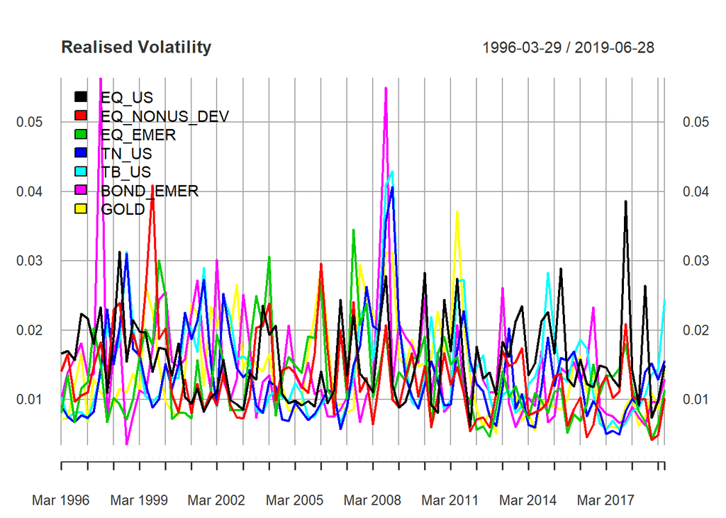

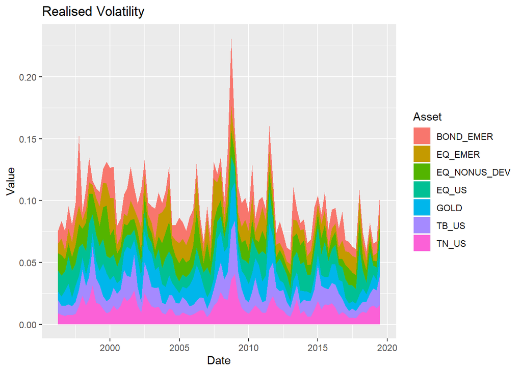

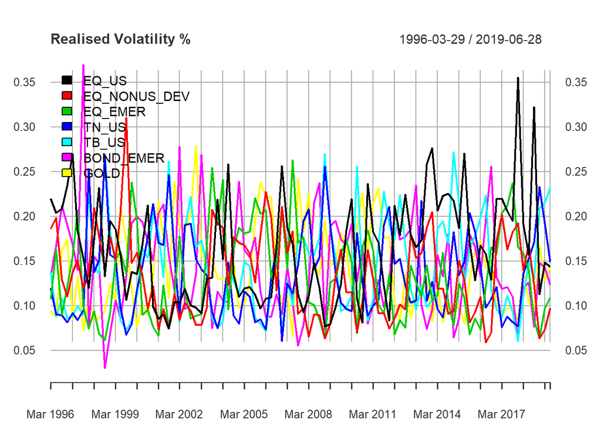

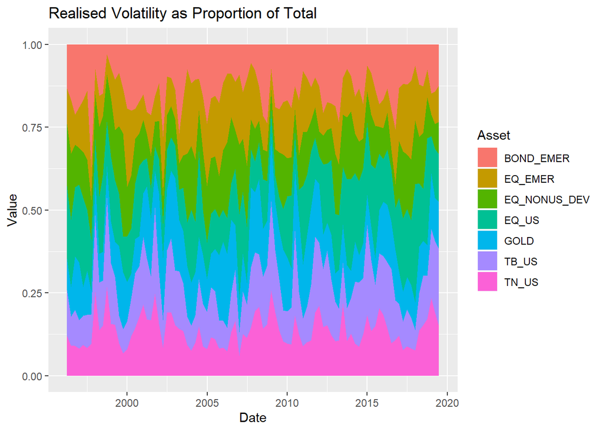

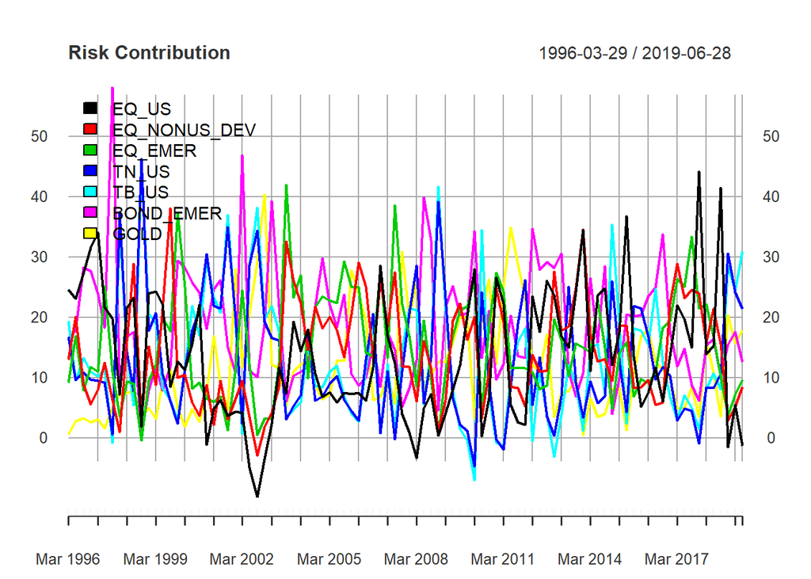

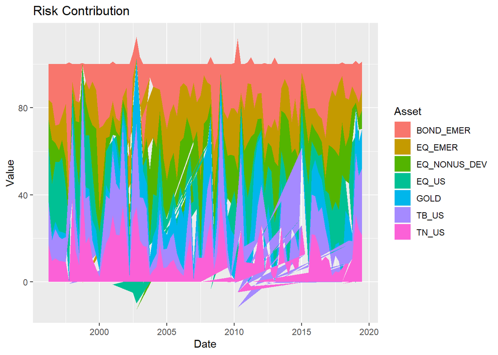

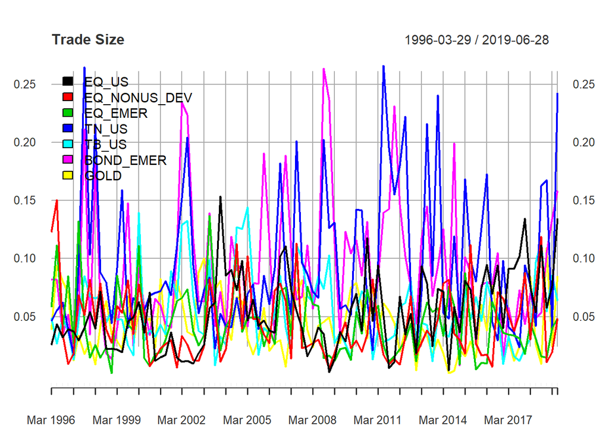

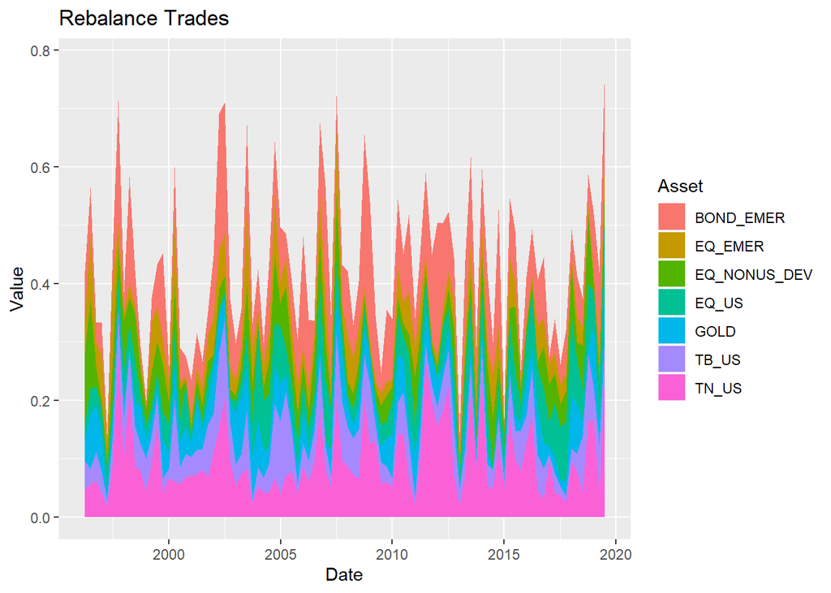

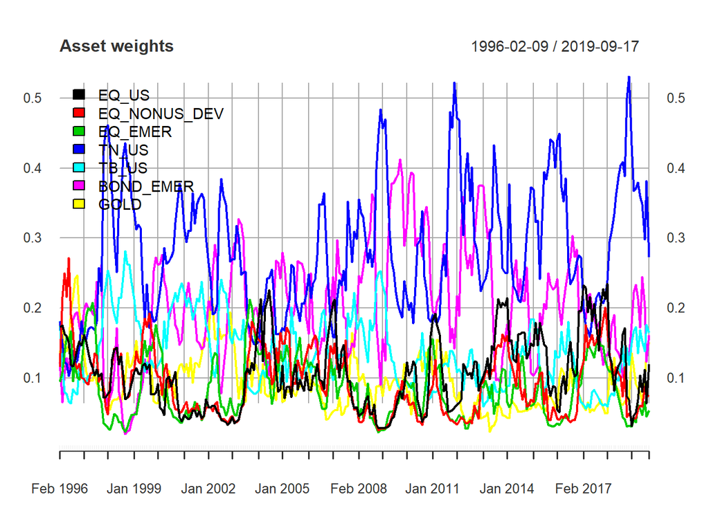

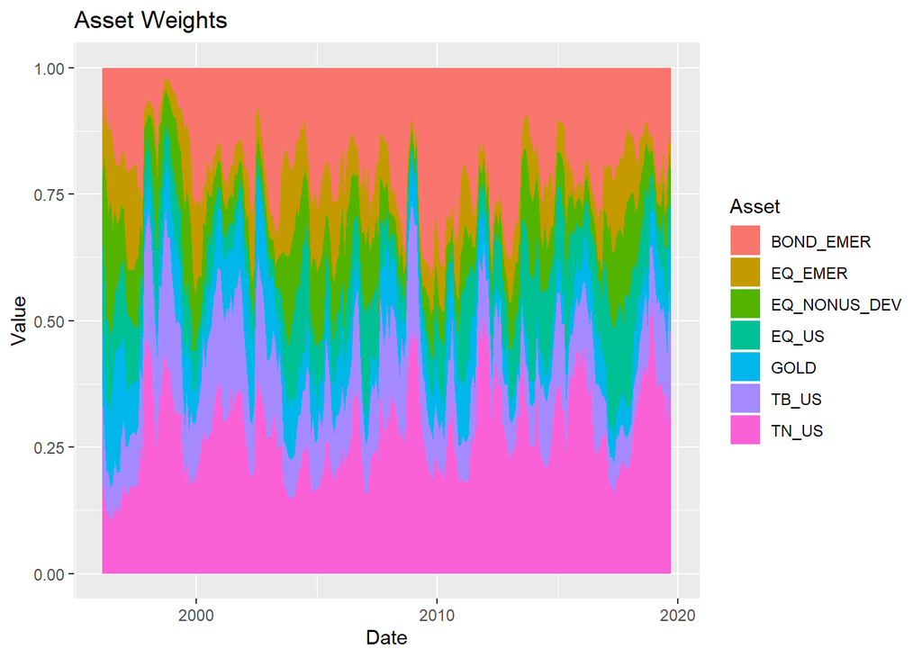

```
##
## Semi Deviation                 0.0026
## Gain Deviation                 0.0022
## Loss Deviation                 0.0025
## Downside Deviation (MAR=210%)  0.0088
## Downside Deviation (Rf=0%)     0.0024
## Downside Deviation (0%)        0.0024
## Maximum Drawdown               0.1923
## Historical VaR (95%)          -0.0054
## Historical ES (95%)           -0.0080
## Modified VaR (95%)            -0.0056
## Modified ES (95%)             -0.0100
##         From     Trough         To   Depth Length To Trough Recovery
## 1 2008-03-03 2008-10-27 2009-08-24 -0.1923    374       167      207
## 2 2018-01-29 2018-10-29 2019-06-20 -0.0913    351       191      160
## 3 2004-04-02 2004-05-17 2004-10-29 -0.0853    146        31      115
## 4 2013-05-09 2013-06-24 2014-04-24 -0.0852    242        32      210
## 5 2000-03-28 2000-05-23 2000-08-31 -0.0773    110        40       70
```

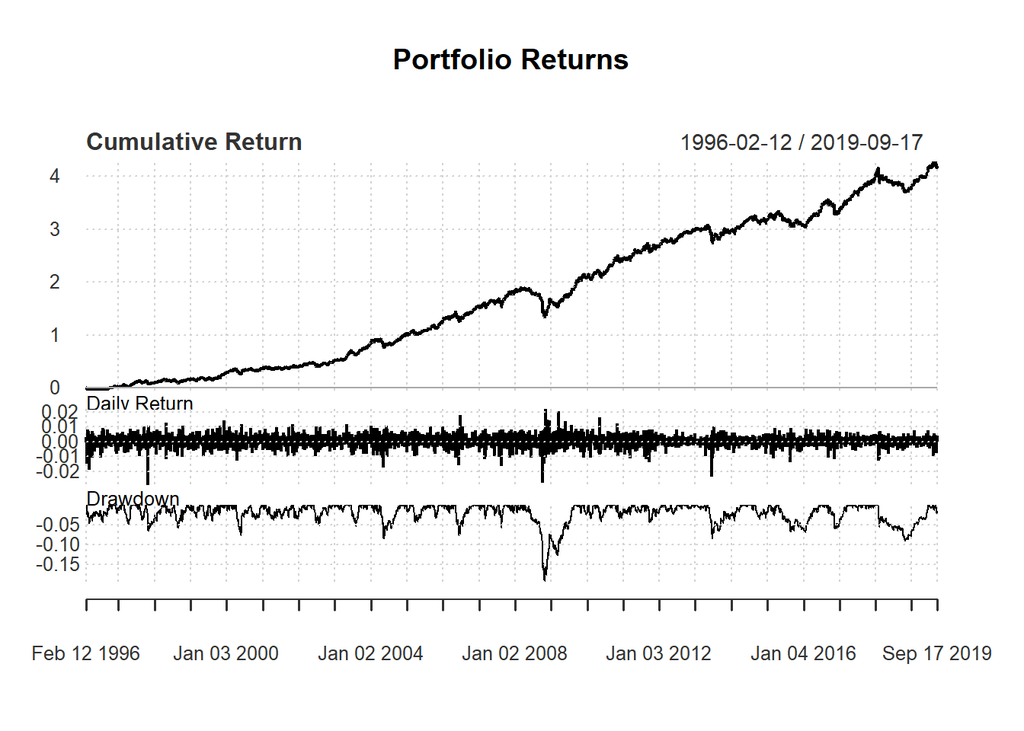

```
##   trackerror_vol trackerror_mrc mean_tradesize cagr sharpe
## 1       4.312778       7.972945      0.4281995 7.24  1.303
```

```
##   trackerror_vol trackerror_mrc mean_tradesize cagr sharpe
## 1       4.312778       7.972945      0.4281995 7.24  1.303
```

```r
unl_weights <- get_unlevered_target_weights(returns_daily, rebal = 22, vol_lookback = 90, cor_lookback = 120, cor_shrinkage = 1, adjust_momo = TRUE, momo_multiplier = 0.1)
# compare to unlevered veresion
riskperformance(returns_daily, weights= unl_weights)
```

The tracking error values were used extensively in strategy development to tune the ERC algorithm and come up with a trade-off in trying to minimise trading cost and tracking error.

Its a high performing strategy so you could leverage it up effectively in a Portfolio Margin account - but that’s a bigger discussion than we have time for here. Rather, let’s just look if we might be able to increase the returns slightly by making use of ETFs with embedded leverage.

## Judiciously using leveraged ETFs to enhance strategy returns

We know that TN_US (US treasury notes) take up a lot of the $ exposure, as they’re the lowest volatility asset in the portfolio.

To keep things simple we have avoided discussion of leverage options. However, when we trade this we have access to leveraged ETFs with embedded leverage.

Let’s look at what happens if we use a leveraged ETF instead of TN_US. We’ll do this cruedly by multiplying TN_US returns by 3. (Note that this will overestimate returns somewhat, due to the increased expense fees of leveraged ETFs.)

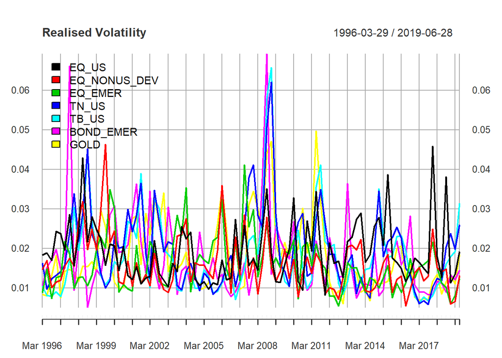

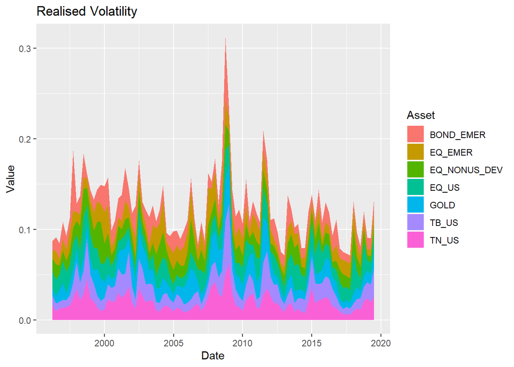

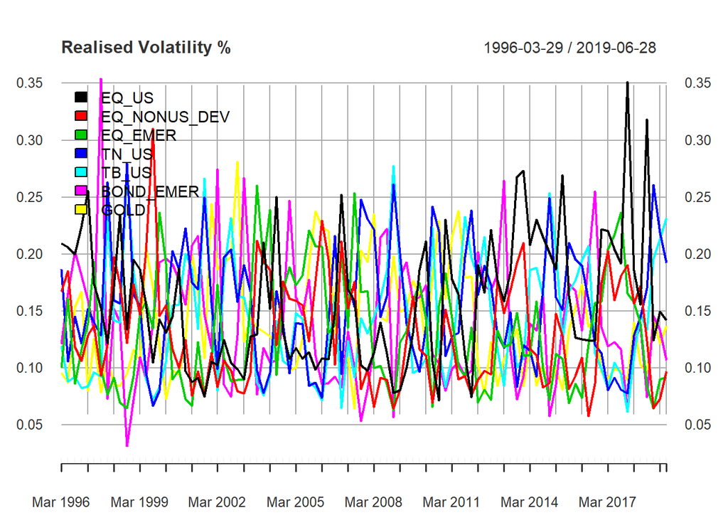

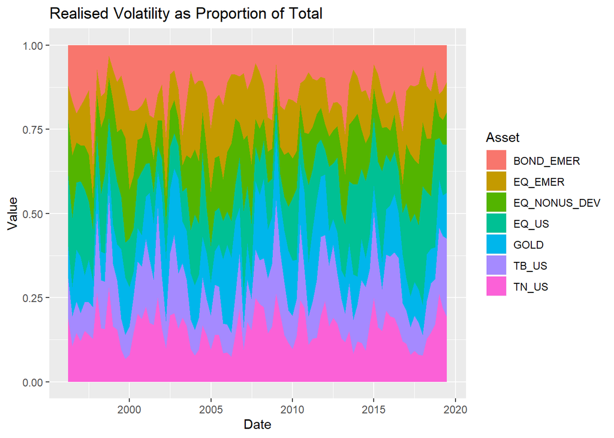

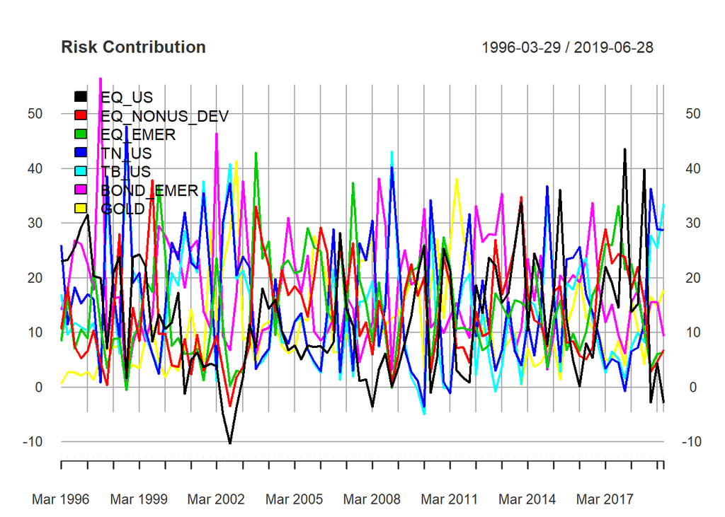

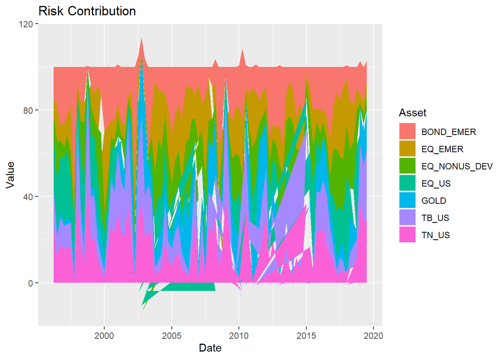

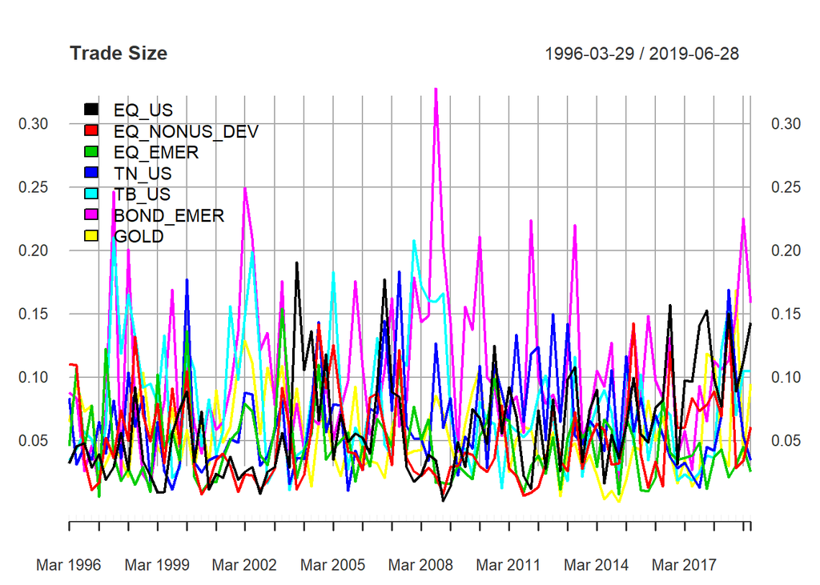

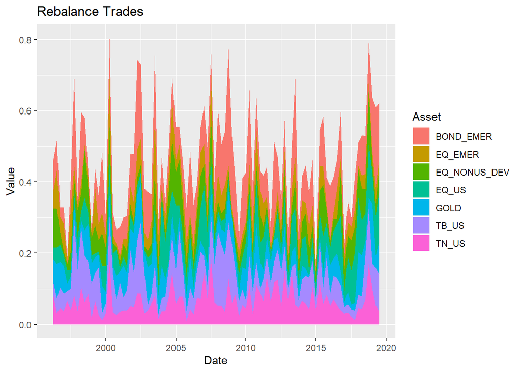

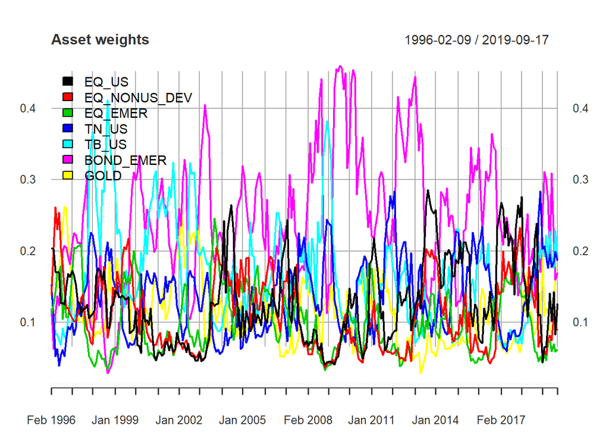

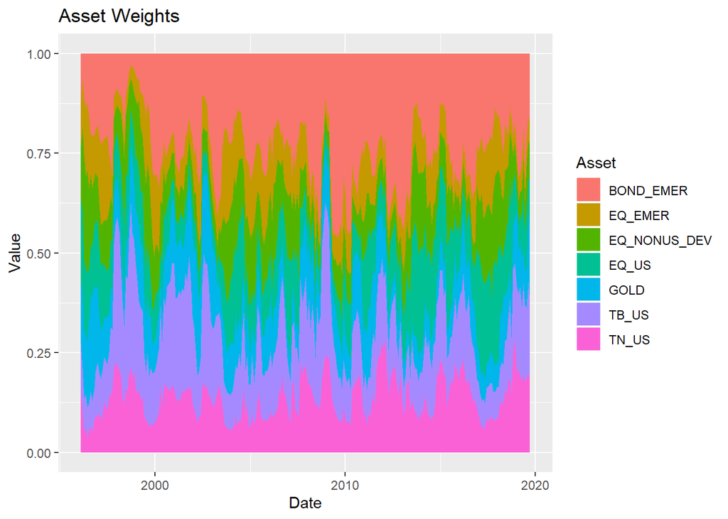

```
##
## Semi Deviation                 0.0032
## Gain Deviation                 0.0028
## Loss Deviation                 0.0032
## Downside Deviation (MAR=210%)  0.0091
## Downside Deviation (Rf=0%)     0.0030
## Downside Deviation (0%)        0.0030
## Maximum Drawdown               0.2418
## Historical VaR (95%)          -0.0067
## Historical ES (95%)           -0.0100
## Modified VaR (95%)            -0.0069
## Modified ES (95%)             -0.0121
##         From     Trough         To   Depth Length To Trough Recovery
## 1 2008-03-03 2008-10-27 2009-08-24 -0.2418    374       167      207
## 2 2018-01-29 2018-10-29 2019-06-18 -0.1167    349       191      158
## 3 2013-05-09 2013-06-24 2014-04-09 -0.1072    232        32      200
## 4 2004-04-02 2004-05-17 2004-10-29 -0.0986    146        31      115
## 5 2000-03-28 2000-05-23 2000-08-31 -0.0949    110        40       70
```

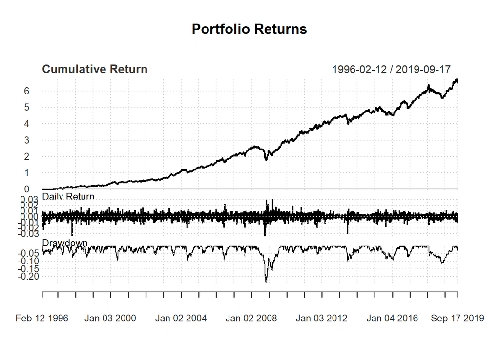

```
##   trackerror_vol trackerror_mrc mean_tradesize cagr sharpe
## 1       4.310882       8.085543      0.4631784 8.97 1.2922
```

```
##   trackerror_vol trackerror_mrc mean_tradesize cagr sharpe
## 1       4.310882       8.085543      0.4631784 8.97 1.2922
```

```r
returns_enhanced <- returns_daily
returns_enhanced$TN_US <- returns_enhanced$TN_US * 3
# Calculate strategy
unl_weights_enhanced <- get_unlevered_target_weights(returns_enhanced, rebal = 22, vol_lookback = 90, cor_lookback = 120, cor_shrinkage = 1, adjust_momo = TRUE, momo_multiplier = 0.1)
# compare to unlevered veresion
riskperformance(returns_enhanced, weights= unl_weights_enhanced)
```

This looks like a fairly good trade-off.

## Run Out-of-Sample Backtest on the ETFs we’re trading

Since December 2018 we’ve been running the strategy with the following ETF assets:

- VTI - US Equity
- PUTW - US S&P500 Systematic Put Writes
- VEA - DM Equity ex US
- VWO - EM Equity
- TLT - US Treasury Bond
- UST - US Treasury Note (Leveraged x2)
- EMB - EM Bonds
- VNQI - International REITs
- GBTC - Bitcoin proxy

### Get ETF Data

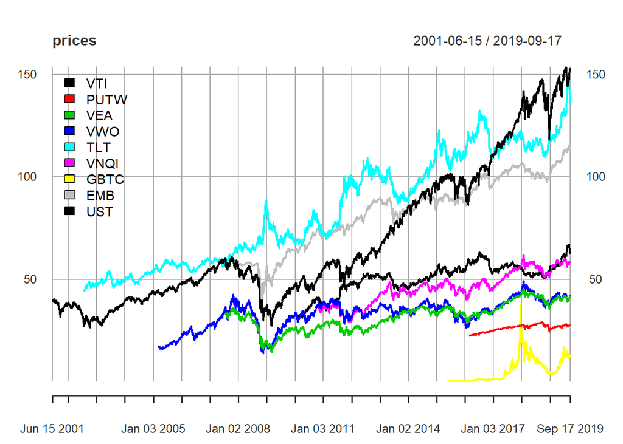

```r
close_from_resilio <- function(etf, date_format="%Y%m%d") {
  prices = read.table(paste0(DATA_FOLDER, '/RiskPremia', '/', etf, '.csv'), header=TRUE, sep=",", row.names="Date")
  prices <- as.xts(prices$Close, order.by = as.Date(rownames(prices), format = date_format))
  colnames(prices) <- etf
  return(prices)
}

etftickers <- c('VTI','PUTW','VEA','VWO','TLT','VNQI', 'GBTC', 'EMB', 'UST')
prices <- lapply(etftickers, close_from_resilio)
prices <- do.call("cbind", prices)
plot(prices, legend.loc='topleft')
```

### ETF Out-of-sample Backtest

Here we run an out-of-sample “backtest” which correlates to our actual trading performing, assuming no trading frictions.

We start at Dec 2018 - which is when we first started trading this strategy live.

There are a few extra rules which go into the strategy:

There are two minor amendments we make to these weights:

- We split the US equity weights 50/50 between the VTI and PUTW ETFs.
- Then we constrain the emerging market bond weights so they can take no more than 15% of the total dollar weight. We do this because this asset class includes credit risk which will only turn up at the very worst of times. Our volatility estimator won’t “see” this risk in the data – so we just restrict the maximum size of this allocation.

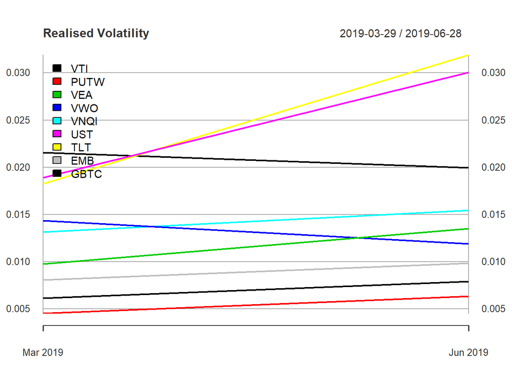

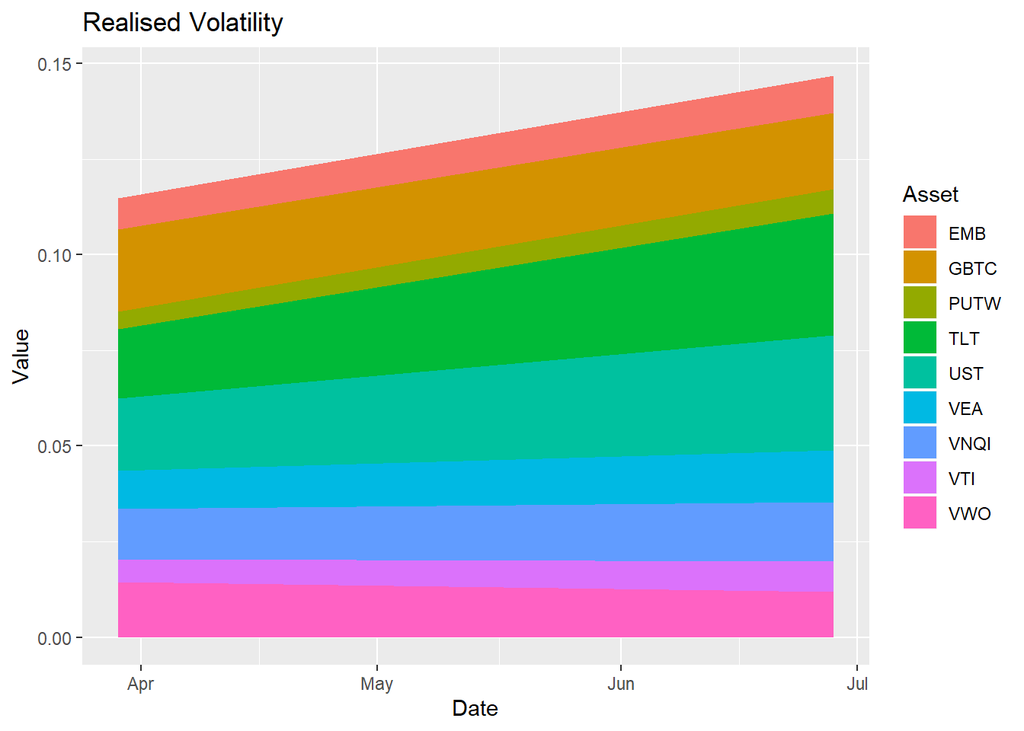

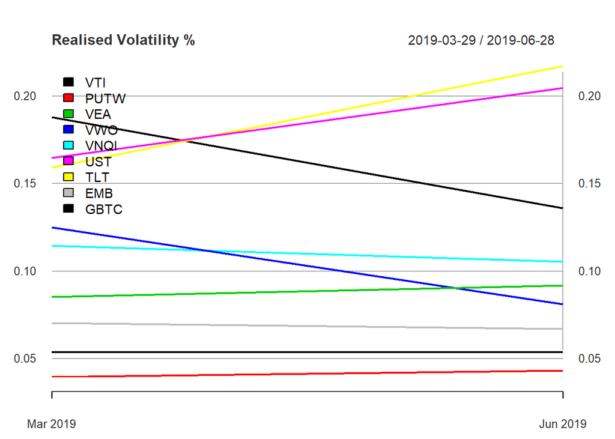

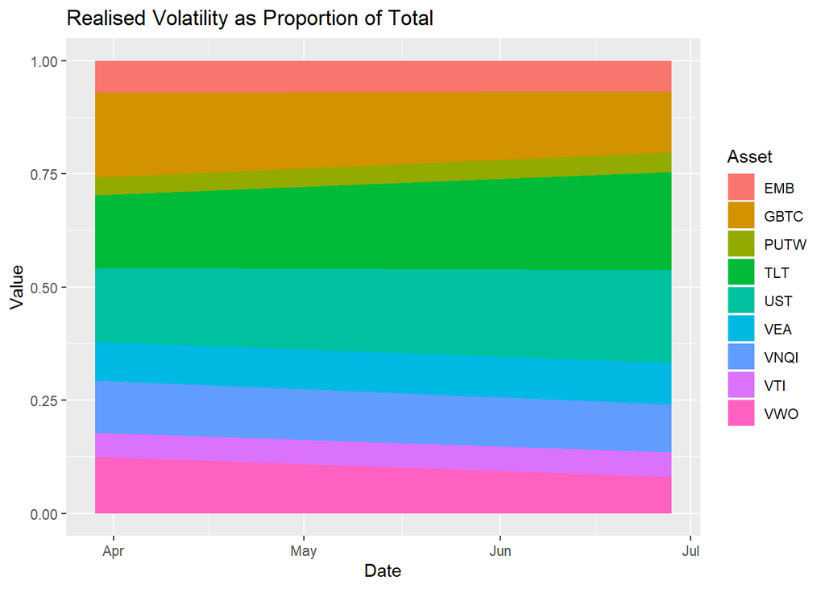

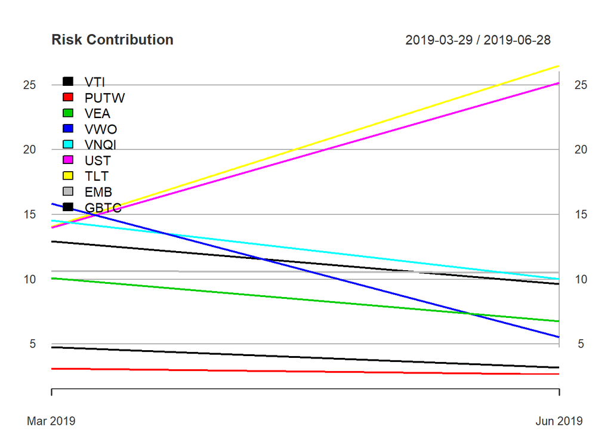

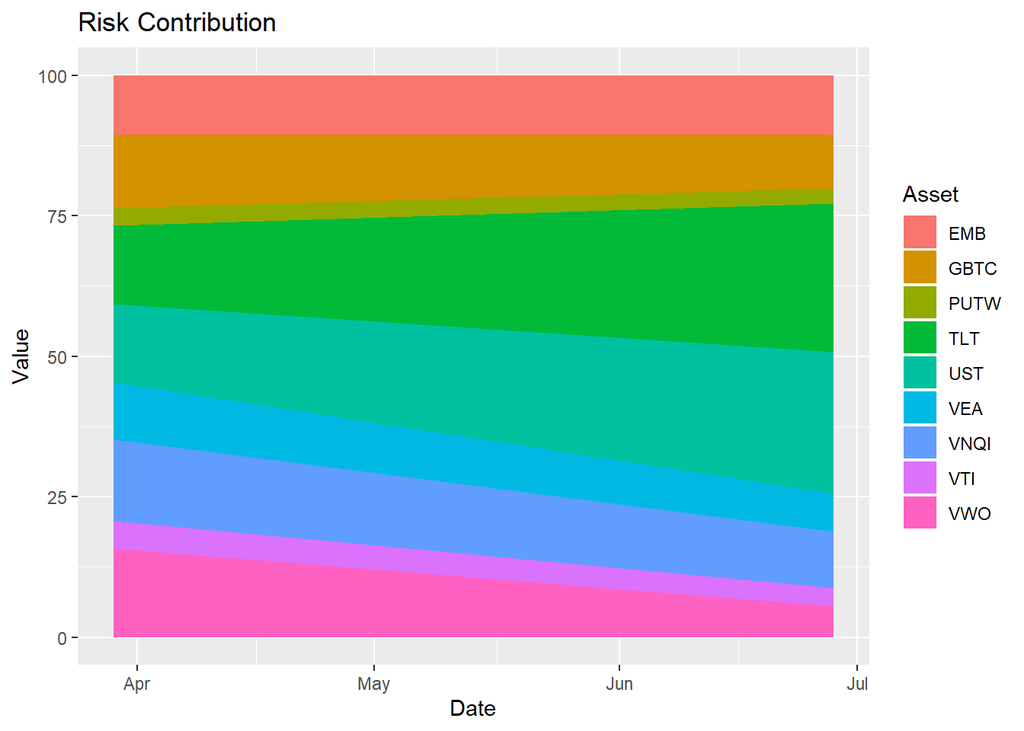

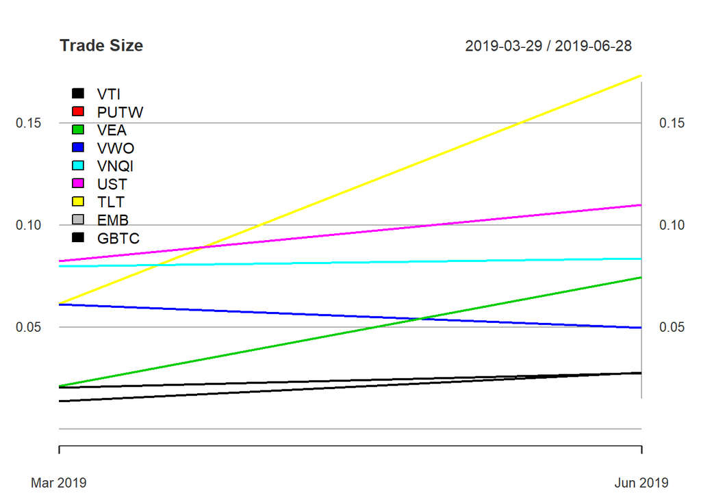

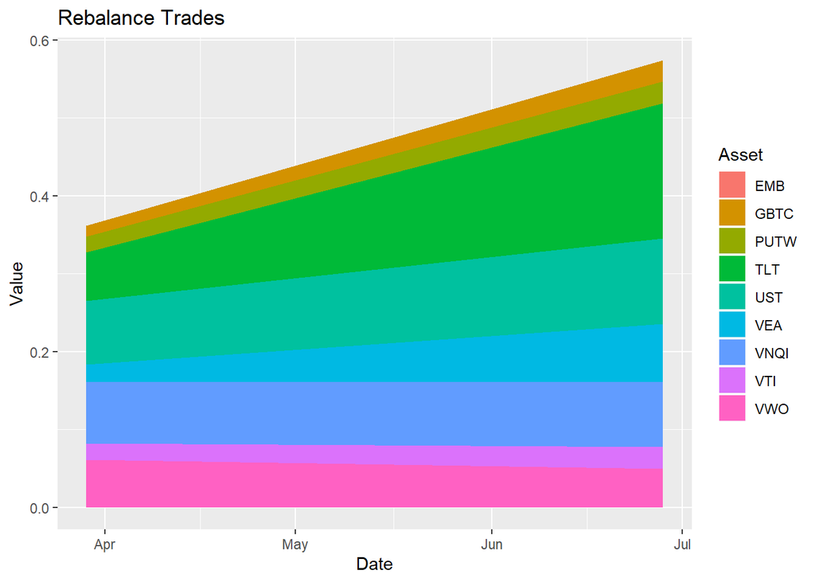

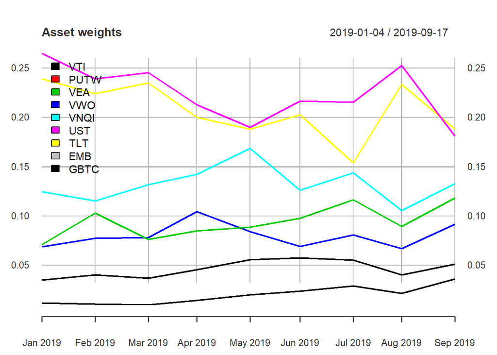

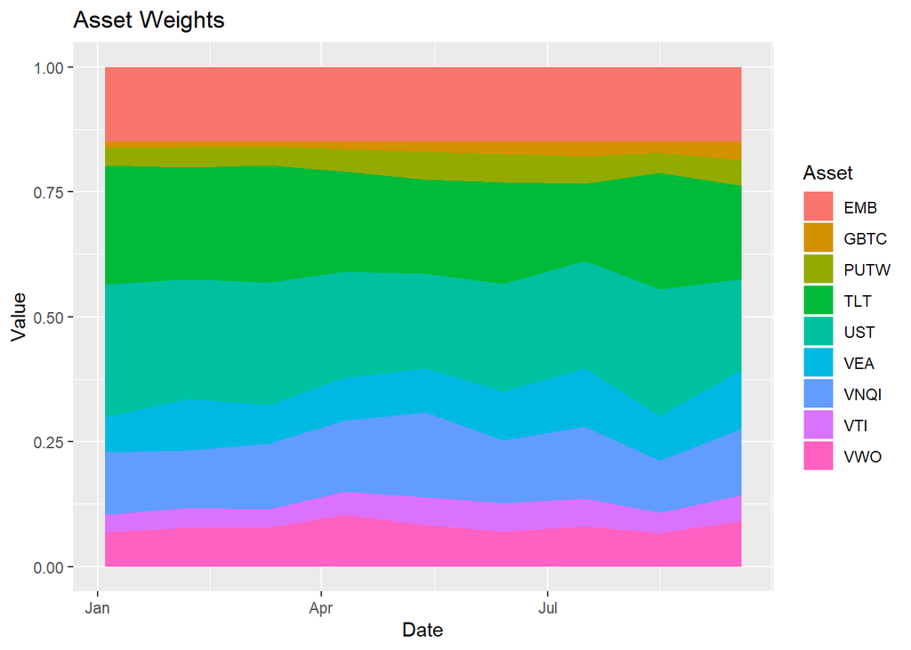

```
##
## Semi Deviation                 0.0027
## Gain Deviation                 0.0023
## Loss Deviation                 0.0025
## Downside Deviation (MAR=210%)  0.0085
## Downside Deviation (Rf=0%)     0.0023
## Downside Deviation (0%)        0.0023
## Maximum Drawdown               0.0323
## Historical VaR (95%)          -0.0060
## Historical ES (95%)           -0.0078
## Modified VaR (95%)            -0.0056
## Modified ES (95%)             -0.0075
##         From     Trough         To   Depth Length To Trough Recovery
## 1 2019-09-05 2019-09-13       <NA> -0.0323     10         7       NA
## 2 2019-07-05 2019-08-05 2019-08-27 -0.0180     38        22       16
## 3 2019-02-27 2019-03-01 2019-03-12 -0.0118     10         3        7
## 4 2019-04-11 2019-05-13 2019-05-24 -0.0104     31        22        9
## 5 2019-02-01 2019-02-13 2019-02-19 -0.0074     12         9        3
```

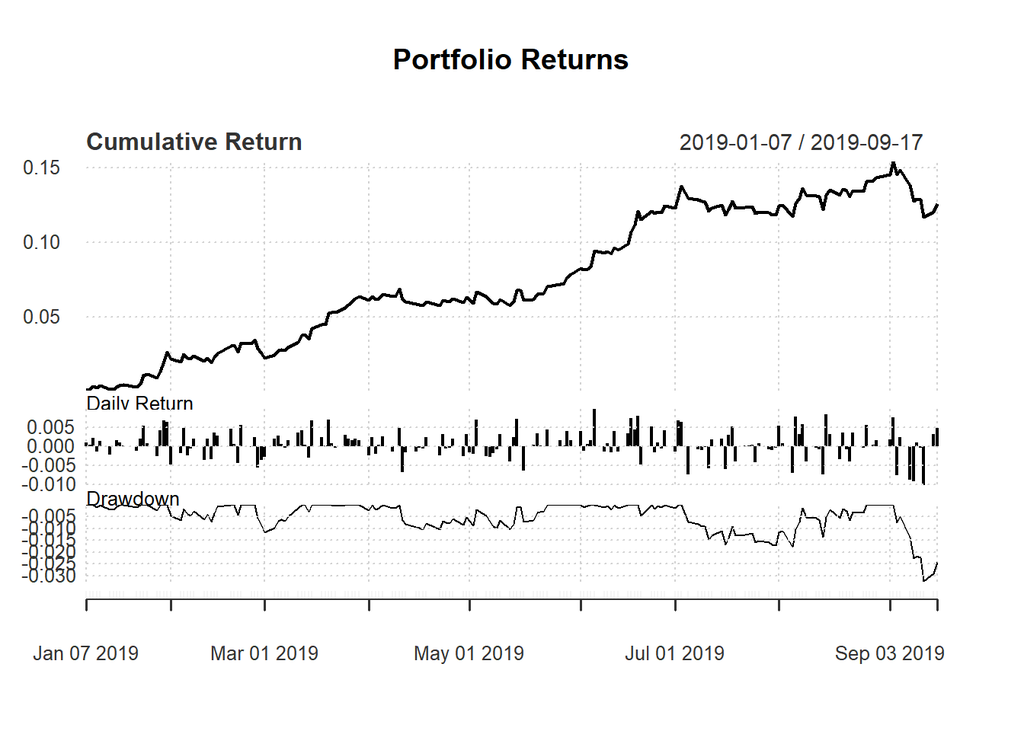

```
##   trackerror_vol trackerror_mrc mean_tradesize  cagr sharpe
## 1       4.668866       5.022192      0.4679366 18.54 3.1573
```

```
##   trackerror_vol trackerror_mrc mean_tradesize  cagr sharpe
## 1       4.668866       5.022192      0.4679366 18.54 3.1573
```

```r
subsetprices <- prices['2017::']
etf_returns <- na.omit(Return.calculate(subsetprices, method='discrete'))

# Exclude PUTW from weight algo. We just give it half the VTI weight.
weight_etf_returns <- subset(etf_returns, select=-PUTW)
# Get weights excluding PUTW
unl_etf_weights <- get_unlevered_target_weights(weight_etf_returns, rebal = 22, vol_lookback = 90, cor_lookback = 120, cor_shrinkage = 1, adjust_momo = TRUE, momo_multiplier = 0.1)

# Update weights so that PUTW gets half the VTI weights
unl_etf_weights$PUTW <- unl_etf_weights$VTI * 0.5
unl_etf_weights$VTI <- unl_etf_weights$VTI * 0.5

# Restrict EMB exposures to 15%, due to concerns over potential credit risk negative skews which won't appear in the data
EMB_weight_cap <- 0.15
EMBWeights <- replace(unl_etf_weights$EMB, unl_etf_weights$EMB > EMB_weight_cap, EMB_weight_cap)

# Rescale weights back to 1
weights_ex_EMB <- subset(unl_etf_weights, select = -EMB)
weights_ex_EMB <- (1-EMB_weight_cap) * weights_ex_EMB / rowSums(weights_ex_EMB)
unl_etf_weights <- cbind(weights_ex_EMB, EMBWeights)

# Ensure returns matrix in xts object is in the same order as in the backtest
etf_backtest_returns <- etf_returns[,c('VTI','PUTW','VEA','VWO','VNQI','UST','TLT','EMB','GBTC')]
etf_backtest_weights <- unl_etf_weights[,c('VTI','PUTW','VEA','VWO','VNQI','UST','TLT','EMB','GBTC')]

# Subset so we're only reporting on the live trading record
etf_backtest_returns <- etf_backtest_returns['2018-12::']
etf_backtest_weights <- etf_backtest_weights['2018-12::']

# Generate performance charts
riskperformance(etf_backtest_returns, weights=etf_backtest_weights)
```

## Display latest ETF weights

```r
tail(etf_backtest_weights,1)
```

```
##                   VTI       PUTW       VEA        VWO      VNQI       UST
## 2019-09-17 0.05098617 0.05098617 0.1182571 0.09173665 0.1328474 0.1809074
##                  TLT  EMB       GBTC
## 2019-09-17 0.1880694 0.15 0.03620973
```

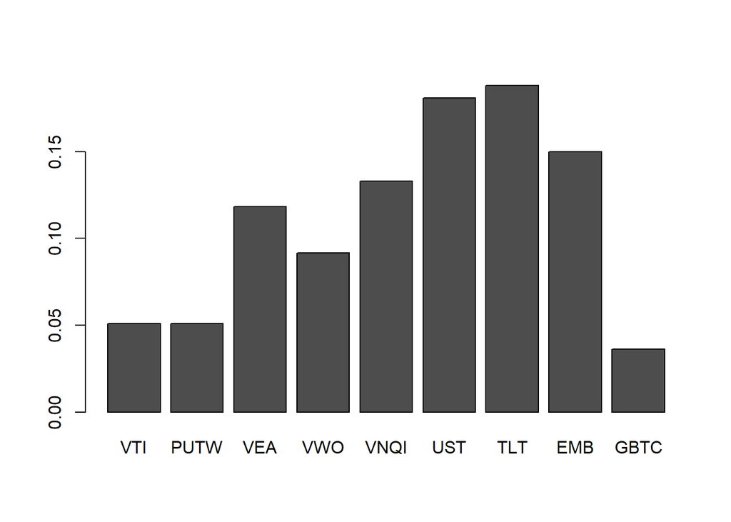

```r
barplot(coredata(tail(etf_backtest_weights,1)))
```